# Car Accident

The first Scatter plot shows the relationship between the speed limit, road surface condition and number of casualties. From the graph, one can see most casualties occur during car speed of 30h/mile and bad (1) road condition.

```r
source("../03 R SQL Visualizations/scatter.R", echo = TRUE)
```

```
##
## > require(tidyr)
```

```
##
## > require(dplyr)
```

```
##
## > require(tm)
```

```
##
## > require(wordcloud)
```

```
##
## > require(RCurl)
```

```
##
## > require(plyr)
```

```
##
## > require(ggplot2)
```

```
##
## > require(jsonlite)
```

```
##
## > Traffic <- data.frame(fromJSON(getURL(URLencode("skipper.cs.utexas.edu:5001/rest/native/?query=\"select * from ROAD_ACCIDENT\""),
## +     httpheader  .... [TRUNCATED]
##
## > straff = ddply(Traffic, .(SPEED_LIMIT, ROAD_SURFACE_CONDITIONS),
## +     summarize, count = sum(NUMBER_OF_CASUALTIES))
##
## > ggplot(straff, aes(y = ROAD_SURFACE_CONDITIONS, x = SPEED_LIMIT,
## +     size = count)) + geom_point(shape = 1, color = "blue")
```

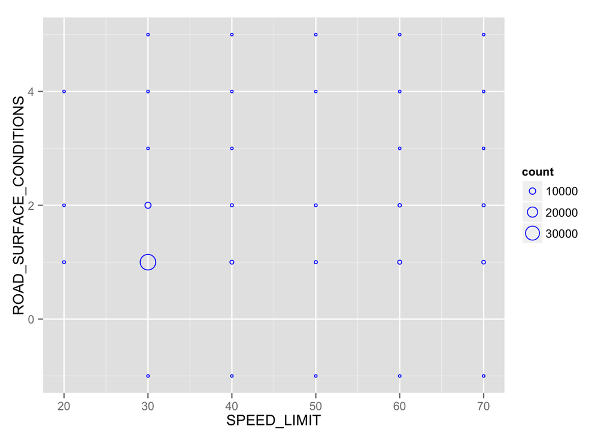

```r
source("../03 R SQL Visualizations/crosstab.R", echo = TRUE)
```

```
##
## > require(tidyr)
##
## > require(dplyr)
##
## > require(tm)
##
## > require(wordcloud)
##
## > require(RCurl)
##
## > require(plyr)
##
## > require(ggplot2)
##
## > require(jsonlite)
##
## > Traffic <- data.frame(fromJSON(getURL(URLencode("skipper.cs.utexas.edu:5001/rest/native/?query=\"select * from ROAD_ACCIDENT\""),
## +     httpheader  .... [TRUNCATED]
##
## > straff = ddply(Traffic, .(SPEED_LIMIT, ROAD_SURFACE_CONDITIONS),
## +     summarize, counting = sum(NUMBER_OF_CASUALTIES), cpv = sum(NUMBER_OF_CASUALT .... [TRUNCATED]
##
## > ggplot(straff, aes(y = ROAD_SURFACE_CONDITIONS, x = SPEED_LIMIT)) +
## +     geom_text(aes(label = counting, color = cpv))
```

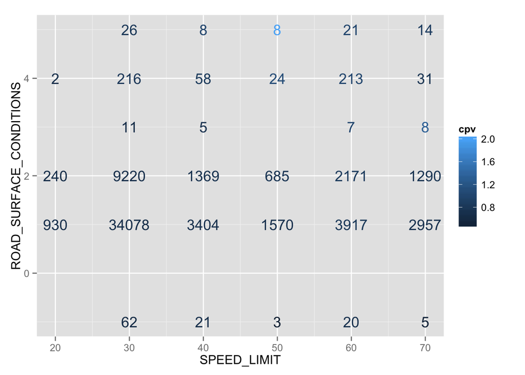

The bar chart shows the effect of weather conditions and road conditions. From the graph, one can see that a majority of accidents happend in poor weather conditions (1). The big difference between individual bars and the average also shows that road condition has an affect on the occurance of accidents.

```
##
## > require(tidyr)
##
## > require(dplyr)
##
## > require(tm)
##
## > require(wordcloud)
##
## > require(RCurl)
##
## > require(plyr)
##
## > require(ggplot2)
##
## > require(jsonlite)
##
## > Traffic <- data.frame(fromJSON(getURL(URLencode("skipper.cs.utexas.edu:5001/rest/native/?query=\"select * from ROAD_ACCIDENT\""),
## +     httpheader  .... [TRUNCATED]
##
## > chart = ddply(Traffic, .(WEATHER_CONDITIONS, ROAD_SURFACE_CONDITIONS),
## +     summarize, count = sum(NUMBER_OF_CASUALTIES), avg = mean(NUMBER_OF_CAS .... [TRUNCATED]
##
## > ggplot(chart, aes(x = ROAD_SURFACE_CONDITIONS, y = count)) +
## +     geom_bar(colour = "blue", fill = "blue", stat = "identity") +
## +     facet_wrap( .... [TRUNCATED]
```

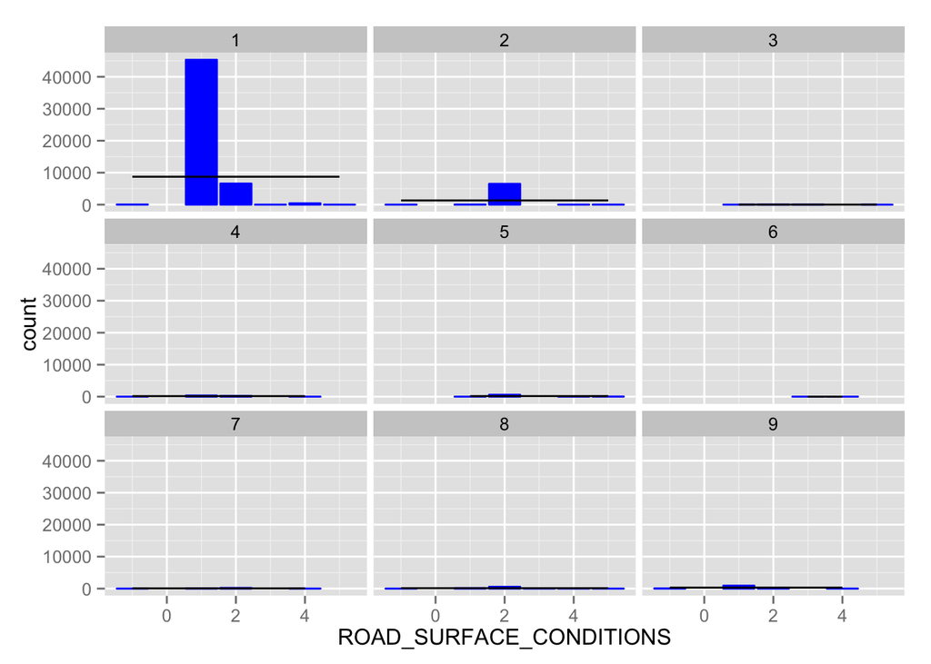

```r
source("../03 R SQL Visualizations/barchart.R", echo = TRUE)
```

The left joined data set shows the air pollution of each day in 2014. A simple analysis of the data shows that there seems to be no correlation between the air pollution and the number of casualties.

```
##
## > require(tidyr)
##
## > require(dplyr)
##
## > require(tm)
##
## > require(wordcloud)
##
## > require(RCurl)
##
## > require(plyr)
##
## > require(ggplot2)
##
## > Traffic <- data.frame(fromJSON(getURL(URLencode("skipper.cs.utexas.edu:5001/rest/native/?query=\"select * from ROAD_ACCIDENT\""),
## +     httpheader  .... [TRUNCATED]
##
## > Air <- data.frame(fromJSON(getURL(URLencode("skipper.cs.utexas.edu:5001/rest/native/?query=\"select * from AIR6\""),
## +     httpheader = c(DB = "jdb ..." ... [TRUNCATED]
##
## > LeftJoin <- dplyr::left_join(Traffic, Air, by = c(DATE_ = "END_DATE"))
##
## > scatt = ddply(LeftJoin, .(NUMBER_OF_CASUALTIES, NO2,
## +     PM10), )
##
## > ggplot(scatt, aes(y = NO2, x = NUMBER_OF_CASUALTIES,
## +     size = PM10)) + geom_point(shape = 1, color = "blue")
```

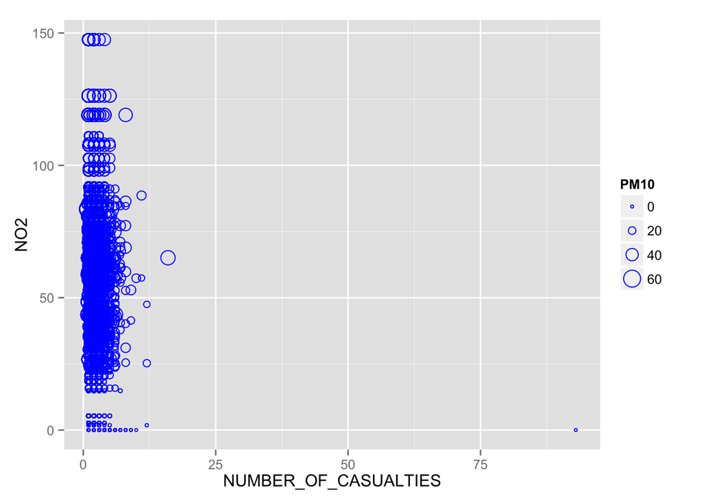

```r
source("../03 R SQL Visualizations/blendplot.R", echo = TRUE)
```